# Machine Learning Project

Ahsan Ahmad, Varun Selvam, Nikita Muddapati

2024-12-04

# Question Prompts

**1. Which machine learning methods did you implement?**

We implemented the following machine learning methods:

1. Penalized Regression (Ridge, Lasso, Elastic Net)
2. Support Vector Machines (Linear and Radial Kernels)
3. XGBoost
4. Principal Component Analysis (PCA)
5. K-Means Clustering
6. Artificial Neural Networks (ANN)
7. Random Forest

**2. Discuss the key contribution of each method to your analysis.**

XGBoost: Although XGBoost is generally known for its performance, it underperformed here with a relatively high RMSE and lower 𝑅2 , suggesting it might not suit this dataset or require further hyperparameter tuning.

Principal Component Analysis (PCA): PCA reduced dimensionality and helped identify the most influential predictors. While it did not directly improve predictive performance, it provided valuable insights into feature importance and guided feature selection for other models.

K-Means Clustering: K-Means offered an unsupervised view of the data, grouping houses into clusters. While clustering was not directly predictive, it could be useful for segmenting markets or identifying hidden patterns in the data.

Artificial Neural Networks (ANN): ANN demonstrated excellent generalization, achieving the second-best RMSE and 𝑅2 values. This method is robust for capturing complex, non-linear relationships in the data.

Random Forest: Random Forest effectively captured complex patterns and prediction accuracy but highlighted tendency of overfitting.

**3. Did all methods support your conclusions or did some provide conflicting results? If so, how did you reconcile the differences?**

Not all methods supported the same conclusions.

# Load Libraries

```r
pacman::p_load(DDoutlier,tidyverse,glmnet,car,psych,
               forecast,lmtest,caret,Metrics,rpart,
               rpart.plot,reshape2,rminer,matrixStats,
               knitr,e1071,lattice,tictoc,ISLR,dataPreparation,
               mlbench,ROCR,tidymodels,dbscan,parallel,factoextra,cluster,gridExtra,doParallel,dials,
               readxl,dplyr,ranger,themis,ggplot2)

library(RWeka)
library(kernlab)
library(yardstick)
```

# Read in Dataset

```r
house_prices <- read.csv("C:/Users/nikit/Downloads/Machine Learning/train_house_prices.csv")
```

# Cleaning the Dataset

This dataset has a few issues which must be addressed through cleaning. Outliers must also be addressed. Afterwards, the dataset can be utilized for modelling.

## Address Missing Values

```r
# Define function to check %age of NAs in each column

find_na <- function(x) sum(is.na(x))

# Apply function to each column with map()
missing_values <- map(.x = house_prices, .f = find_na) %>%
  unlist() %>%
  data.frame()

missing_values %>%
  filter(. != 0) %>%
  mutate(pctg = ./nrow(house_prices)) %>%
  arrange(desc(pctg)) %>%
  round(4)
```

|  | . | pctg |
| --- | --- | --- |
| PoolQC | 1453 | 0.9952 |
| MiscFeature | 1406 | 0.9630 |
| Alley | 1369 | 0.9377 |
| Fence | 1179 | 0.8075 |
| FireplaceQu | 690 | 0.4726 |
| LotFrontage | 259 | 0.1774 |
| GarageType | 81 | 0.0555 |
| GarageYrBlt | 81 | 0.0555 |
| GarageFinish | 81 | 0.0555 |
| GarageQual | 81 | 0.0555 |

[output cut: 9 more lines]

### Address Columns greater than 90% of NA’s

#### Check Levels for Variables

The below code checks the levels for the variables that have more than 90% of their values missing.

```r
unique(house_prices$PoolQC)
```

```
## [1] NA   "Ex" "Fa" "Gd"
```

```r
unique(house_prices$MiscFeature)
```

```
## [1] NA     "Shed" "Gar2" "Othr" "TenC"
```

```r
unique(house_prices$Alley)
```

```
## [1] NA     "Grvl" "Pave"
```

Per the Kaggle Dictionary, Na for `PoolQC` means that there is no pool. Thus, these NA values can be replaced with “No Pool”

Additionally, per the Kaggle Dictionary, NA for `MiscFeature` means that there is no Miscellaneous Feature in the house. These NA values can also be replaced with “No Misc Feature”.

Finally NA for `Alley` means that there is no Alley Access for that house. Hence NA for this column can also be replaced with “No Alley”.

#### Recode PoolQC

```r
# Recoding cols

# Recode NA in FireplaceQu to "No Fireplace"
house_prices$PoolQC[is.na(house_prices$PoolQC)] <- "No Pool"

# Check that recoding the NA values worked
unique(house_prices$PoolQC)
```

```
## [1] "No Pool" "Ex"      "Fa"      "Gd"
```

#### Recode MiscFeature

```r
# Recode NA in MiscFeature to "No Misc Feature"
house_prices$MiscFeature[is.na(house_prices$MiscFeature)] <- "No Misc Feature"

# Check that recoding the NA values worked
unique(house_prices$MiscFeature)
```

```
## [1] "No Misc Feature" "Shed"            "Gar2"            "Othr"
## [5] "TenC"
```

#### Recode Alley

```r
# Recode NA in MiscFeature to "No Misc Feature"
house_prices$Alley[is.na(house_prices$Alley)] <- "No Alley"

# Check that recoding the NA values worked
unique(house_prices$Alley)
```

```
## [1] "No Alley" "Grvl"     "Pave"
```

## Address Remaining Missing Values

```r
# use above function again to check %age of remaining columns' NA's (<90%)
# recode cols again/impute numeric cols with median and categorical cols with mode

missing_values <- map(.x = house_prices, .f = find_na) %>%
  unlist() %>%
  data.frame()

missing_values %>%
  filter(. != 0) %>%
  mutate(pctg = ./nrow(house_prices)) %>%
  arrange(desc(pctg))
```

|  | . | pctg |
| --- | --- | --- |
| Fence | 1179 | 0.8075342466 |
| FireplaceQu | 690 | 0.4726027397 |
| LotFrontage | 259 | 0.1773972603 |
| GarageType | 81 | 0.0554794521 |
| GarageYrBlt | 81 | 0.0554794521 |
| GarageFinish | 81 | 0.0554794521 |
| GarageQual | 81 | 0.0554794521 |
| GarageCond | 81 | 0.0554794521 |
| BsmtExposure | 38 | 0.0260273973 |
| BsmtFinType2 | 38 | 0.0260273973 |

[output cut: 6 more lines]

#### Analyze Fence Quality

```r
unique(house_prices$Fence)
```

```
## [1] NA      "MnPrv" "GdWo"  "GdPrv" "MnWw"
```

The “Fence Quality” is a categorical variable that contains 4 categories: * MnPrv * GdWo * GdPrv * MnWw.

Per the Kaggle Competition Website, this column describes the quality of the fence for a property. The Kaggle Website also states that “NA” represents “No Fence”.

Thus, NA can be recoded as “No Fence”

```r
# Recode NA in Fence to "No Fence"
house_prices$Fence[is.na(house_prices$Fence)] <- "No Fence"

# Check that recoding the NA values worked
unique(house_prices$Fence)
```

```
## [1] "No Fence" "MnPrv"    "GdWo"     "GdPrv"    "MnWw"
```

Recoding the NA Values was successful.

#### Analyze Fireplace Qu

`Fireplace Qu` stands for Fireplace Quality and describes the quality of a fireplace. Additionally Kaggle states that NA means that the home does not have a fireplace.

Thus, any NA values will be recoded to represent “No Fireplace”.

```r
# Recode NA in FireplaceQu to "No Fireplace"
house_prices$FireplaceQu[is.na(house_prices$FireplaceQu)] <- "No Fireplace"

# Check that recoding the NA values worked
unique(house_prices$FireplaceQu)
```

```
## [1] "No Fireplace" "TA"           "Gd"           "Fa"           "Ex"
## [6] "Po"
```

#### Analyze Lot Frontage

```r
# Select only numeric columns
numeric_data <- house_prices %>%
  select(-Id,-OverallQual,-OverallCond,-MSSubClass) %>%
  select(where(is.numeric))

# Calculate the correlation matrix
cor_matrix <- cor(numeric_data, use = "complete.obs")

# Extract correlations for LotFrontage
lotfrontage_correlations <- cor_matrix["LotFrontage", ]

# Display the correlations
lotfrontage_correlations
```

```
##   LotFrontage       LotArea     YearBuilt  YearRemodAdd    MasVnrArea
##  1.0000000000  0.4211841021  0.1097255707  0.0864139680  0.1899685917
##    BsmtFinSF1    BsmtFinSF2     BsmtUnfSF   TotalBsmtSF     X1stFlrSF
##  0.2413522339  0.0493053240  0.1153058755  0.3876195129  0.4510850287
##     X2ndFlrSF  LowQualFinSF     GrLivArea  BsmtFullBath  BsmtHalfBath
##  0.0750038007  0.0111480855  0.3963060214  0.1180881480  0.0004335725
##      FullBath      HalfBath  BedroomAbvGr  KitchenAbvGr  TotRmsAbvGrd
##  0.1857853092  0.0456783485  0.2704038861 -0.0035464716  0.3484211056
##    Fireplaces   GarageYrBlt    GarageCars    GarageArea    WoodDeckSF
##  0.2603208280  0.0698781184  0.2865868103  0.3568509373  0.0821656268
##   OpenPorchSF EnclosedPorch    X3SsnPorch   ScreenPorch      PoolArea
##  0.1618151174  0.0142610142  0.0697157667  0.0359059844  0.2117461173
##       MiscVal        MoSold        YrSold     SalePrice
##  0.0014707377  0.0188145348  0.0132670710  0.3442697721
```

Lot Frontage does not seem to be strongly correlated with any of the numeric variables. Thus, using a package like Amelia might not be very appropriate. (Amelia would basically create a model that takes the other columns and uses them to predict potential values for the other columns.)

It should also be noted that although the correlation with the Target Variable `SalePrice` is quite low at .34, it could be still be useful in combination with other variables.

However in terms of dealing with the NA’s, imputation with the median should be fairly reliable. The column is only missing 17.74% of its values. This means that utilizing the median should be reliable since most of the column’s values (82.26%) are present.

```r
# Compute the median
median_lot_frontage <- median(house_prices$LotFrontage,na.rm = TRUE)   # median= 69

median_lot_frontage
```

```
## [1] 69
```

```r
# Impute with the median
house_prices$LotFrontage[is.na(house_prices$LotFrontage)] <- median_lot_frontage

# Check Missing Values
sum(is.na(house_prices$LotFrontage))
```

```
## [1] 0
```

#### Analyze all the Garage Variables

The Garage Variables all are missing 81 variables which comprise 5.55% of the dataset:

- `GarageType`
- `GarageYrBlt`
- `GarageFinish`
- `GarageQual`
- `GarageCond`

According to Kaggle, NA for `GarageType`, `GarageFinish`, `GarageQual`, `GarageCond` represents “No Garage”. This means that the NA value can be recoded as “No Garage” for the above columns.

NA for “Garage Built” however will be a little tricky since including a number like 0 or -9999 or 1 to represent no Garage may confuse any ensemble models. This is because the model may believe that 1 or -9999 is a valid year.

Thus, to avoid any potential confusion or creating possible outliers like 9999, we will just leave NA in `GarageYrBlt` alone. (We can’t replace it with a string like “No Garage” because the column type will change and it’ll no longer be numeric.)

Instead, a new column will be created that more explicitly states whether a house has a garage or not. Thus, a new column will be created wtih “0” representing no garage and “1” representing a garage. (This info can be gleaned from the other Garage Columns but we believe that having an explicit column for Garage will make it easier to assess Garage’s influence on price and it can be used to compare houses that don’t have garages vs having a garage for clustering as well. (We may do clustering and then run a model on that cluster, so having this column will be helpful for that as well.)

```r
# create a vector to store all the columns
garage_col <- c("GarageType", "GarageFinish", "GarageQual", "GarageCond")

# Replace NA in specified columns with new value
house_prices <- house_prices %>%
  mutate(across(all_of(garage_col), ~ replace_na(., "No Garage")))
```

The new column `HasGarage` has been created to represent explicitly whether a house has a garage or not.

```r
house_prices <- house_prices %>%
  mutate(HasGarage = ifelse(is.na(GarageYrBlt), "No", "Yes")  # Create a binary indicator for garage presence
  )
```

#### Analyze all the Basement Variables

According to Kaggle, NA for `BsmtExposure`, `BsmtFinType2`, `BsmtQual`, `BsmtCond` and `BsmtFinType1` represents “No Basement”. This means that the NA value can be recoded as “No Basement” for the above columns.

They are also all missing roughly the same amount of values in all the columns.

```r
# create a vector to store all the columns
basement_col <- c("BsmtExposure", "BsmtFinType2", "BsmtQual", "BsmtCond","BsmtFinType1")

# Replace NA in specified columns with new value
house_prices <- house_prices %>%
  mutate(across(all_of(basement_col), ~ replace_na(., "No Basement")))
```

#### Analyze all the MasVnr Variables

Kaggle states that if there is no Masonry Veneer for the house, then the value is “None” for the `MasVnrType` variable. This indicates that the variable is genuinely missing values. (i.e any NA values are geniunely missing values and cannot be imputed with “None”)

Additionally, if a house does not have a Masonry Veneer, then the `MasVnrArea` is zero. The below code chunk shows this:

```r
house_prices %>%
  select(MasVnrType,MasVnrArea) %>% # Select the following two columns
  filter(MasVnrType == "None") %>% # Only select rows where client marked "None".
  head()
```

|  | MasVnrType | MasVnrArea |
| --- | --- | --- |
| 1 | None | 0 |
| 2 | None | 0 |
| 3 | None | 0 |
| 4 | None | 0 |
| 5 | None | 0 |
| 6 | None | 0 |

The code shows that everytime `MasVnrType` is None, the `MasVnrArea` variable is Zero. Despite this, there are only 8 values missing in both columns which is less than 1% of the data at 0.54% This is a very small amount which means that imputing with median/mode is appropriate.

```r
# Define function to find the mode of a character vector
find_mode <- function(x){
  table(x) %>%
    which.max() %>%
    names()
}

# Compute with the median
MasVnrType_mode <- find_mode(house_prices$MasVnrType)

MasVnrType_mode
```

```
## [1] "None"
```

```r
# Impute with the median
house_prices$MasVnrType[is.na(house_prices$MasVnrType)] <- MasVnrType_mode  # mode = "None"

# Check Missing Values
sum(is.na(house_prices$MasVnrType))
```

```
## [1] 0
```

```r
# Compute with the median
median_MasVnrArea <- median(house_prices$MasVnrArea,na.rm = TRUE)  #median = 0
median_MasVnrArea
```

```
## [1] 0
```

```r
# Impute with the median
house_prices$MasVnrArea[is.na(house_prices$MasVnrArea)] <- median_MasVnrArea

# Check Missing Values
sum(is.na(house_prices$MasVnrArea))
```

```
## [1] 0
```

MasVnrType has been successfully imputed with the mode while MasVnrArea has also been successfully imputed with the median.

#### Analyze Electrical Variable

The Electrical Variable is only missing one observation. This missing value can be replaced with the mode since it’s a categorical variable.

```r
# Get the mode for electrical
electrical_mode <- find_mode(house_prices$Electrical)

# Impute with the mode
house_prices$Electrical[is.na(house_prices$Electrical)] <- electrical_mode

# Check missing values
sum(is.na(house_prices$Electrical))
```

```
## [1] 0
```

The imputation was successful, there are no missing values, except for `GarageYrBlt` This however was done on purpose, please see “Analyze all the Garage Variables” for more information.

```r
map(.x = house_prices, .f = find_na) %>%
  unlist() %>%
  data.frame()
```

|  | . |
| --- | --- |
| Id | 0 |
| MSSubClass | 0 |
| MSZoning | 0 |
| LotFrontage | 0 |
| LotArea | 0 |
| Street | 0 |
| Alley | 0 |
| LotShape | 0 |
| LandContour | 0 |
| Utilities | 0 |

[output cut: 72 more lines]

## Drop ID Column

```r
# Drop Id column not needed
house_prices <- house_prices %>%
  select(-Id)
```

The Id Column is dropped since it is just used to identify each individual house. It does not say anything else or reveal any interesting characteristics about the house.

## Factor Conversion

```r
# Factoring all categorical and numeric variables

# Mutate any character variables into factors
house_prices <- house_prices %>% mutate_if(is.character, as.factor)

# Numeric Variables which should be factors stored as a vector
cat_values <- c("OverallQual","OverallCond","MSSubClass", "MoSold")

# Utilize mutate to transform all the columns in the cat_values vector to factors.
house_prices <- house_prices %>%
  mutate(across(all_of(cat_values), as.factor))

# Display the summary of train_clean
summary(house_prices)
```

```
##    MSSubClass     MSZoning     LotFrontage        LotArea        Street
##  20     :536   C (all):  10   Min.   : 21.00   Min.   :  1300   Grvl:   6
##  60     :299   FV     :  65   1st Qu.: 60.00   1st Qu.:  7554   Pave:1454
##  50     :144   RH     :  16   Median : 69.00   Median :  9478
##  120    : 87   RL     :1151   Mean   : 69.86   Mean   : 10517
##  30     : 69   RM     : 218   3rd Qu.: 79.00   3rd Qu.: 11602
##  160    : 63                  Max.   :313.00   Max.   :215245
##  (Other):262
##       Alley      LotShape  LandContour  Utilities      LotConfig    LandSlope
##  Grvl    :  50   IR1:484   Bnk:  63    AllPub:1459   Corner : 263   Gtl:1382
##  No Alley:1369   IR2: 41   HLS:  50    NoSeWa:   1   CulDSac:  94   Mod:  65
##  Pave    :  41   IR3: 10   Low:  36                  FR2    :  47   Sev:  13
##                  Reg:925   Lvl:1311                  FR3    :   4
##                                                      Inside :1052
##
##
##   Neighborhood   Condition1     Condition2     BldgType      HouseStyle
##  NAmes  :225   Norm   :1260   Norm   :1445   1Fam  :1220   1Story :726
##  CollgCr:150   Feedr  :  81   Feedr  :   6   2fmCon:  31   2Story :445
##  OldTown:113   Artery :  48   Artery :   2   Duplex:  52   1.5Fin :154
##  Edwards:100   RRAn   :  26   PosN   :   2   Twnhs :  43   SLvl   : 65
##  Somerst: 86   PosN   :  19   RRNn   :   2   TwnhsE: 114   SFoyer : 37
##  Gilbert: 79   RRAe   :  11   PosA   :   1                 1.5Unf : 14
##  (Other):707   (Other):  15   (Other):   2                 (Other): 19
##   OverallQual   OverallCond    YearBuilt     YearRemodAdd    RoofStyle
##  5      :397   5      :821   Min.   :1872   Min.   :1950   Flat   :  13
##  6      :374   6      :252   1st Qu.:1954   1st Qu.:1967   Gable  :1141
##  7      :319   7      :205   Median :1973   Median :1994   Gambrel:  11
##  8      :168   8      : 72   Mean   :1971   Mean   :1985   Hip    : 286
##  4      :116   4      : 57   3rd Qu.:2000   3rd Qu.:2004   Mansard:   7
##  9      : 43   3      : 25   Max.   :2010   Max.   :2010   Shed   :   2
##  (Other): 43   (Other): 28
##     RoofMatl     Exterior1st   Exterior2nd    MasVnrType    MasVnrArea
##  CompShg:1434   VinylSd:515   VinylSd:504   BrkCmn : 15   Min.   :   0.0
##  Tar&Grv:  11   HdBoard:222   MetalSd:214   BrkFace:445   1st Qu.:   0.0
##  WdShngl:   6   MetalSd:220   HdBoard:207   None   :872   Median :   0.0
##  WdShake:   5   Wd Sdng:206   Wd Sdng:197   Stone  :128   Mean   : 103.1
##  ClyTile:   1   Plywood:108   Plywood:142                 3rd Qu.: 164.2
##  Membran:   1   CemntBd: 61   CmentBd: 60                 Max.   :1600.0
##  (Other):   2   (Other):128   (Other):136
```

[output cut: 81 more lines]

```
##  GdPrv   :  59   Gar2           :   2   Min.   :    0.00   6      :253
##  GdWo    :  54   No Misc Feature:1406   1st Qu.:    0.00   7      :234
##  MnPrv   : 157   Othr           :   2   Median :    0.00   5      :204
##  MnWw    :  11   Shed           :  49   Mean   :   43.49   4      :141
##  No Fence:1179   TenC           :   1   3rd Qu.:    0.00   8      :122
##                                         Max.   :15500.00   3      :106
##                                                            (Other):400
##      YrSold        SaleType    SaleCondition    SalePrice      HasGarage
##  Min.   :2006   WD     :1267   Abnorml: 101   Min.   : 34900   No :  81
##  1st Qu.:2007   New    : 122   AdjLand:   4   1st Qu.:129975   Yes:1379
##  Median :2008   COD    :  43   Alloca :  12   Median :163000
##  Mean   :2008   ConLD  :   9   Family :  20   Mean   :180921
##  3rd Qu.:2009   ConLI  :   5   Normal :1198   3rd Qu.:214000
##  Max.   :2010   ConLw  :   5   Partial: 125   Max.   :755000
##                 (Other):   9
```

This code will all the character variables along with some numeric variables to factors.

- `OverallQual` is being converted because the numeric ratings have a categorical values with them. i.e 10 is “very excellent” while 9 is “excellent”. Thus to capture these categorical values, `OverallQual` is being converted to a factor. (This info is from the data dictionary on Kaggle.)
  - Overall Quality rates the overall material and finish of the house.
- `OverallCond` also reflect this with the numeric rating containing categorical information. For instance, a 9 is “excellent” while an 8 is “very good”. (This info is from the data dictionary on Kaggle.)
  - Overall Cond rates the overall condition of the house.
- `MSSubclass` also contains categorical information which has been represented as a numeric variable. Thus, to capture this information, this variable will also be converted to a factor. For instance, “20” represents a “1-STORY 1946 & NEWER ALL STYLES”
  - Identifies the type of dwelling involved in a sale.
- `MoSold` just represents the month that a house was sold. This should be a categorical variable, it makes no sense to calculate the “median” month, etc. There additionally is no meaningful numeric diference between “January” and “February” for instance. These are just names of the months which this variable represents. It has just been created as a numeric column.

## Outliers Analysis

To remove the outliers, the LOF (Local Outlier Factor) algorithm will be utilized. This approach utilizes LOOP (Local Outlier Probability) where it utilizes the LOF Scores to calculate the probability of an observation being an outlier.

Afterwards any observations that have a greater than 75% probability of being an outlier will be removed from the dataset.

```r
numeric_columns <- sapply(house_prices, is.numeric)

house_clean_numeric <- house_prices[, numeric_columns] # subset train_clean using only numeric cols  (33 cols)

house_clean_numeric <- house_clean_numeric %>% select(-GarageYrBlt)
# Can't have missing values

lof<- sapply(5:10, function(k) LOF(house_clean_numeric,k))
```

This above code calculates 6 LOF Values for each row in the dataset. For instance, for row 1, the chunk will calculate the LOF for 5 neighbors, 6 neighbors, etc. up to 10 neighbors.

```r
#calcuate median lof of different neighborhood sizes.

lof<-apply(lof,1,median)
```

The above code then calculates the median LOF score for each row from the 6 LOF scores previously generated for each row.

```r
loop<- sapply(5:10, function(k) LOOP(house_clean_numeric,k))
loop<-apply(loop,1,median)

# Remove observation with LOOP more than .75
# hpc = house_prices_clean
hpc <- house_prices[loop <= 0.75, ]
```

There is the issue of selecting which probabilty threshold should be selected for determining if something is an outlier. However, the median LOF Scores which are used to calculate the LOOP should provide a better view than just using LOF Scores from a fixed neighbor number. (i.e calculating the LOF Scores from just 6 neighbors for every observation.)

```r
row_reduction_02 <- ((1460 - nrow(hpc))/1460) * 100

round(row_reduction_02,2)
```

```
## [1] 1.44
```

```r
nrow(hpc)
```

```
## [1] 1439
```

```r
ncol(hpc)
```

```
## [1] 81
```

## Visualize the distribution of the SalePrice

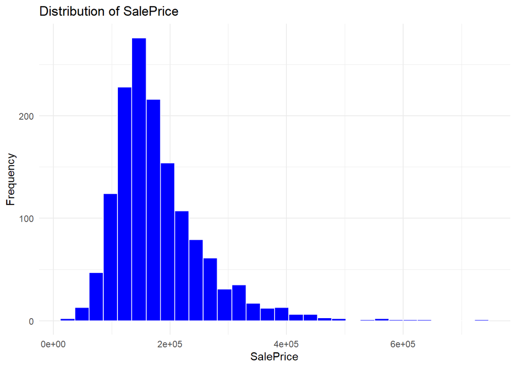

```r
ggplot(hpc, aes(SalePrice)) +
  geom_histogram(bins = 30, fill = "blue", color = "white") +
  theme_minimal() +
  labs(title = "Distribution of SalePrice", x = "SalePrice", y = "Frequency")
```

# Penalized Regression

## Partition the Dataset

```r
#Ridge Regression cannot handle missing values, there is one column yr built which has missing values, so this colulmn will be removed.
hpc_01 <- hpc %>%
  select(-GarageYrBlt)

set.seed(100) # Set Seed for reproducibility
index_row_number_split <- createDataPartition(hpc_01$SalePrice,p=.8,list = FALSE) #Split into 80/20 with 80 in split and 20 in train
```

```r
# Subset train using the index and assign it to train_fold.
train_fold <- hpc_01[index_row_number_split, ]

# Subset all remaining rows into the validation fold.
test <- hpc_01[-index_row_number_split, ]
```

### K-Fold Validation Penalized Regression Function

```r
perform_kfold_cv <- function(X, y, alpha, lambda, k, seed) {
  # Ensure reproducibility
  set.seed(seed)

  # Create k folds
  folds <- sample(1:k, size = nrow(X), replace = TRUE)

  # Initialize vectors to store RMSE and R^2 for each fold
  cv_rmse <- numeric(k)
  cv_r2 <- numeric(k)

  for (i in 1:k) {
    # Split data into training and validation sets
    train_idx <- which(folds != i)
    test_idx <- which(folds == i)

    X_train <- X[train_idx, , drop = FALSE]  # Subset predictors for training
    y_train <- y[train_idx]                  # Subset target for training

    X_test <- X[test_idx, , drop = FALSE]    # Subset predictors for testing
    y_test <- y[test_idx]                    # Subset target for testing

    # Train the model on the training fold
    model <- glmnet(X_train, y_train, alpha = alpha, lambda = lambda)

    # Predict on the validation fold
    predictions <- predict(model, newx = X_test)

    # Calculate RMSE for this fold
    cv_rmse[i] <- sqrt(mean((y_test - predictions)^2))

    # Calculate R^2 for this fold
    ss_total <- sum((y_test - mean(y_test))^2)
    ss_residual <- sum((y_test - predictions)^2)
    cv_r2[i] <- 1 - (ss_residual / ss_total)
  }

  # Calculate average RMSE and R^2 across all folds
  mean_rmse <- mean(cv_rmse)
  mean_r2 <- mean(cv_r2)

  # Print messages with the metrics
  cat("Average RMSE across ", k, "-fold cross-validation: ", round(mean_rmse, 2), "\n")

  cat("Average R^2 across ", k, "-fold cross-validation: ", round(mean_r2, 2), "\n")

}
```

## Ridge Regression

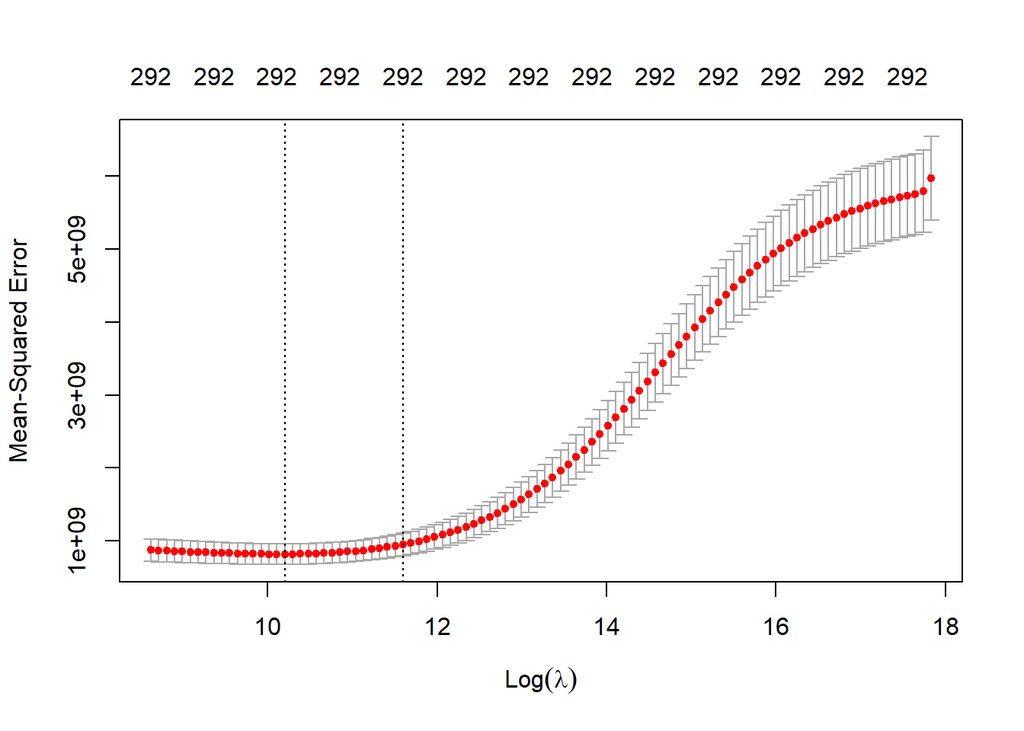

```r
X <- model.matrix(SalePrice ~ ., train_fold)
y <- train_fold$SalePrice

cv_ridge <- cv.glmnet(X, y, alpha = 0)  # alpha = 0 for Ridge
plot(cv_ridge)
```

Introduced L2 regularization to shrink coefficients of less important features.

The Optimal λ (left vertical dashed line) is the first vertical dashed line (around log(λ) ≈ 10). This marks the λ value that minimizes the Mean Squared Error. This value of λ balances the trade-off between bias and variance, giving the best model performance.

High MSE after log(λ) ≈ 12: As λ increases beyond the optimal point, the MSE starts increasing, indicating that the model is becoming overly regularized, leading to underfitting.

The plot shows that the model is performing well in finding an optimal λ that minimizes the prediction error. The region around log(λ) ≈ 10 is the best choice for λ, and choosing a value in this region should provide a good balance between bias and variance.

```r
ridge_best_lambda <- cv_ridge$lambda.min
ridge_model <- glmnet(X, y, alpha = 0, lambda = ridge_best_lambda)

# Displaying ridge model
coef(ridge_model)
```

```
## 299 x 1 sparse Matrix of class "dgCMatrix"
##                                       s0
## (Intercept)                -7.048801e+05
## (Intercept)                 .
## MSSubClass30               -4.524746e+03
## MSSubClass40                4.758746e+03
## MSSubClass45                5.291890e+02
## MSSubClass50                1.305033e+03
## MSSubClass60                2.927752e+03
## MSSubClass70                2.014644e+03
## MSSubClass75                7.023079e+03
## MSSubClass80               -2.323323e+03
## MSSubClass85               -5.388790e+03
## MSSubClass90               -5.246218e+03
## MSSubClass120              -6.774750e+03
## MSSubClass160              -7.137595e+03
## MSSubClass180              -1.779061e+03
## MSSubClass190              -4.336505e+03
## MSZoningFV                  6.717653e+03
## MSZoningRH                  1.673252e+03
## MSZoningRL                  2.841563e+03
## MSZoningRM                 -1.838751e+03
## LotFrontage                 8.365240e+01
## LotArea                     3.665320e-01
## StreetPave                  1.878945e+04
## AlleyNo Alley               2.012051e+03
## AlleyPave                   2.596838e+03
## LotShapeIR2                 1.259002e+04
## LotShapeIR3                -5.757907e+02
## LotShapeReg                 1.057638e+02
## LandContourHLS              8.380324e+03
## LandContourLow             -3.846058e+03
## LandContourLvl              2.181130e+03
## UtilitiesNoSeWa             .
## LotConfigCulDSac            6.917146e+03
## LotConfigFR2               -5.858812e+03
## LotConfigFR3               -2.203019e+03
## LotConfigInside            -1.456972e+03
## LandSlopeMod                3.769061e+03
## LandSlopeSev               -1.022605e+04
```

[output cut: 246 more lines]

```
## YrSold                      1.577045e+02
## SaleTypeCon                 3.001278e+04
## SaleTypeConLD               1.126695e+03
## SaleTypeConLI               4.491595e+02
## SaleTypeConLw              -4.998485e+03
## SaleTypeCWD                 2.638532e+03
## SaleTypeNew                 8.869680e+03
## SaleTypeOth                 2.995639e+03
## SaleTypeWD                 -2.546049e+03
## SaleConditionAdjLand        1.812957e+04
## SaleConditionAlloca         2.166379e+03
## SaleConditionFamily        -4.057335e+03
## SaleConditionNormal         2.900012e+03
## SaleConditionPartial        7.897406e+03
## HasGarageYes                4.073642e+02
```

## Lasso Regression

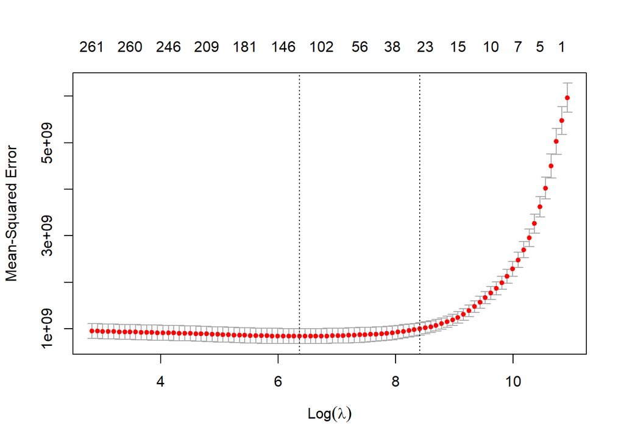

```r
# Lasso Regression
cv_lasso <- cv.glmnet(X, y, alpha = 1)  # alpha = 1 for Lasso
plot(cv_lasso)
```

Applied L1 regularization to perform both coefficient shrinkage and variable selection.

The Lasso Regression performs best with a λ value around log(λ) ≈ 6. Beyond this, as λ increases, the model complexity decreases, but at the cost of predictive performance. (Housing price predictions are less accurate). Beyond that, the plot suggests the model is functioning well in terms of balancing sparsity (feature selection) and prediction accuracy.

```r
lasso_best_lambda <- cv_lasso$lambda.min
lasso_model <- glmnet(X, y, alpha = 1, lambda = lasso_best_lambda)

# Displaying Lasso Model
coef(lasso_model)
```

```
## 299 x 1 sparse Matrix of class "dgCMatrix"
##                                       s0
## (Intercept)                -8.162912e+05
## (Intercept)                 .
## MSSubClass30                .
## MSSubClass40                .
## MSSubClass45                .
## MSSubClass50                .
## MSSubClass60                .
## MSSubClass70                .
## MSSubClass75                .
## MSSubClass80                .
## MSSubClass85                .
## MSSubClass90               -1.534618e+03
## MSSubClass120              -6.232845e+03
## MSSubClass160              -7.002863e+03
## MSSubClass180               .
## MSSubClass190               .
## MSZoningFV                  2.516814e+03
## MSZoningRH                  .
## MSZoningRL                  7.050291e+02
## MSZoningRM                  .
## LotFrontage                 4.650837e+01
## LotArea                     3.238795e-01
## StreetPave                  1.547816e+04
## AlleyNo Alley               .
## AlleyPave                   .
## LotShapeIR2                 1.225821e+04
## LotShapeIR3                 .
## LotShapeReg                 .
## LandContourHLS              2.487686e+03
## LandContourLow              .
## LandContourLvl              1.142279e+03
## UtilitiesNoSeWa             .
## LotConfigCulDSac            6.038254e+03
## LotConfigFR2               -2.556308e+03
## LotConfigFR3                .
## LotConfigInside             .
## LandSlopeMod                .
## LandSlopeSev               -3.540413e+03
```

[output cut: 246 more lines]

```
## YrSold                      .
## SaleTypeCon                 1.666190e+04
## SaleTypeConLD               .
## SaleTypeConLI               .
## SaleTypeConLw               .
## SaleTypeCWD                 .
## SaleTypeNew                 2.224779e+04
## SaleTypeOth                 .
## SaleTypeWD                  .
## SaleConditionAdjLand        8.423880e+03
## SaleConditionAlloca         .
## SaleConditionFamily        -1.612182e+02
## SaleConditionNormal         4.187940e+03
## SaleConditionPartial        .
## HasGarageYes                .
```

## Elastic Net Regression

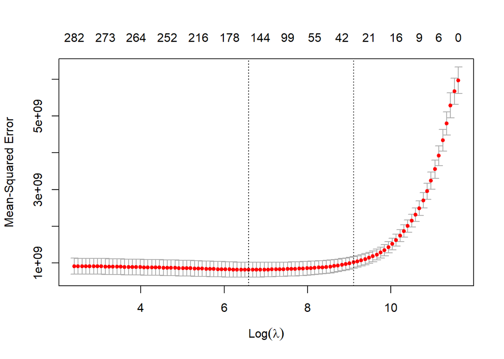

```r
# Elastic Net Regression
cv_elastic_net <- cv.glmnet(X, y, alpha = 0.5)  # alpha = 0.5 for Elastic Net
plot(cv_elastic_net)
```

Combined both L1 and L2 penalties to balance the strengths of Ridge and Lasso. Cross-validation was used to select the optimal lambda (penalty) for each model, which helps control overfitting and improves generalization.

The MSE decreases initially as 𝜆increases (moving from left to right) because the model becomes regularized, reducing overfitting.

However, as𝜆increases further, the MSE starts to rise again because the model becomes too simplistic, shrinking the coefficients too much (underfitting).

- The left vertical line (λ_min) represents the value of where the MSE is minimized. This is the most accurate model in terms of cross-validation error.
- The right vertical line (λ_1se) provides a more parsimonious model (fewer predictors) that still performs within one standard error of the minimum MSE. The minimum MSE occurs around Log(λ) ≈ 6.

```r
elastic_net_best_lambda <- cv_elastic_net$lambda.min
elastic_net_model <- glmnet(X, y, alpha = 0.5, lambda = elastic_net_best_lambda)

# Displaying Elastic Net Model
coef(elastic_net_model)
```

```
## 299 x 1 sparse Matrix of class "dgCMatrix"
##                                       s0
## (Intercept)                -7.437394e+05
## (Intercept)                 .
## MSSubClass30                .
## MSSubClass40                .
## MSSubClass45                .
## MSSubClass50                .
## MSSubClass60                .
## MSSubClass70                .
## MSSubClass75                .
## MSSubClass80                .
## MSSubClass85                .
## MSSubClass90               -9.165137e+02
## MSSubClass120              -7.291464e+03
## MSSubClass160              -7.304550e+03
## MSSubClass180               .
## MSSubClass190               .
## MSZoningFV                  5.338380e+03
## MSZoningRH                  .
## MSZoningRL                  8.386724e+02
## MSZoningRM                  .
## LotFrontage                 3.932546e+01
## LotArea                     3.901446e-01
## StreetPave                  2.012216e+04
## AlleyNo Alley               .
## AlleyPave                   .
## LotShapeIR2                 1.374234e+04
## LotShapeIR3                 .
## LotShapeReg                 2.450765e+02
## LandContourHLS              4.860670e+03
## LandContourLow             -2.093553e+03
## LandContourLvl              2.912554e+03
## UtilitiesNoSeWa             .
## LotConfigCulDSac            6.189874e+03
## LotConfigFR2               -4.383920e+03
## LotConfigFR3                .
## LotConfigInside             .
## LandSlopeMod                2.586965e+03
## LandSlopeSev               -9.235758e+03
```

[output cut: 246 more lines]

```
## YrSold                      .
## SaleTypeCon                 2.511955e+04
## SaleTypeConLD               .
## SaleTypeConLI               .
## SaleTypeConLw               .
## SaleTypeCWD                 .
## SaleTypeNew                 2.254071e+04
## SaleTypeOth                 5.792041e+02
## SaleTypeWD                  .
## SaleConditionAdjLand        1.603107e+04
## SaleConditionAlloca         .
## SaleConditionFamily         .
## SaleConditionNormal         5.494060e+03
## SaleConditionPartial        .
## HasGarageYes                .
```

## Model Evaluation (Forecasting)

```r
round_metrics <- function(x) {
  return(lapply(x, function(y) {
    if (is.numeric(y)) {
      return(round(y, 2))
    } else {
      return(y)
    }
  }))
}
```

### Ridge Regression Model

#### Train Predictions

```r
# Create the same train matrix to utilize for making predictions
newx <- model.matrix(SalePrice ~ ., train_fold)

# Predict
predictions_ridge_train <- predict(ridge_model, newx = newx)

# Create List of Model Metrics for Regression
metrics_list <- c("MAE", "RMSE", "R2", "COR","MAPE","RMSPE","RAE", "RRSE")

# Generate Model Metrics
ridge_train <- mmetric(train_fold$SalePrice,predictions_ridge_train,metrics_list)

round_metrics(ridge_train)
```

```
## $MAE
## [1] 13558.55
##
## $RMSE
## [1] 21043.08
##
## $R2
## [1] 0.93
##
## $COR
## [1] 0.96
##
## $MAPE
## [1] 8
##
## $RMSPE
## [1] 1.28
##
## $RAE
## [1] 23.95
##
## $RRSE
## [1] 27.23
```

#### Test Predictions

```r
# Create matrix for the test data, then make predictions
newx_test <- model.matrix(SalePrice ~ ., test)

# Make Predictions
predictions_ridge_test <- predict(ridge_model, newx = newx_test)

ridge_test <- mmetric(test$SalePrice,predictions_ridge_test,metrics_list)

round_metrics(ridge_test)
```

```
## $MAE
## [1] 15371.32
##
## $RMSE
## [1] 26923.69
##
## $R2
## [1] 0.89
##
## $COR
## [1] 0.94
##
## $MAPE
## [1] 8.58
##
## $RMSPE
## [1] 1.35
##
## $RAE
## [1] 27.52
##
## $RRSE
## [1] 34.27
```

#### 5-fold validation

```r
perform_kfold_cv(X = X, y = y, alpha = 0,lambda = ridge_best_lambda, k = 5, seed = 100)
```

```
## Average RMSE across  5 -fold cross-validation:  28639.64
## Average R^2 across  5 -fold cross-validation:  0.86
```

Implement cross validation for more rigorous evaluation since, model performance can be dependent on a particular split. Not ah huge decrease from the test set $R^2$ which was .89. RMSE also only increased modestly as well.

### Lasso Regression Model

#### Train Predictions

```r
# Generate Predictions
predictions_lasso_train <- predict(lasso_model, newx = newx)

# Generate Train Metrics
lasso_train <- mmetric(train_fold$SalePrice,predictions_lasso_train,metrics_list)
round_metrics(lasso_train)
```

```
## $MAE
## [1] 13406.77
##
## $RMSE
## [1] 20597.62
##
## $R2
## [1] 0.93
##
## $COR
## [1] 0.96
##
## $MAPE
## [1] 8.01
##
## $RMSPE
## [1] 1.3
##
## $RAE
## [1] 23.68
##
## $RRSE
## [1] 26.66
```

#### Test Predictions

```r
# Generate Predictions
predictions_lasso_test <- predict(lasso_model, newx = newx_test)

# Generate Test Metrics
lasso_test <- mmetric(test$SalePrice,predictions_lasso_test,metrics_list)
round_metrics(lasso_test)
```

```
## $MAE
## [1] 15154.86
##
## $RMSE
## [1] 26227.82
##
## $R2
## [1] 0.89
##
## $COR
## [1] 0.94
##
## $MAPE
## [1] 8.39
##
## $RMSPE
## [1] 1.25
##
## $RAE
## [1] 27.13
##
## $RRSE
## [1] 33.39
```

#### 5-Fold Validation

```r
perform_kfold_cv(X = X, y = y, alpha = 0,lambda = lasso_best_lambda, k = 5, seed = 100)
```

```
## Average RMSE across  5 -fold cross-validation:  30836.7
## Average R^2 across  5 -fold cross-validation:  0.84
```

### Elastic Net Regression Model

#### Train Predictions

```r
# Generate Predictions
predictions_elastic_train <- predict(elastic_net_model, newx = newx)

# Generate Train Metrics
elastic_train <- mmetric(train_fold$SalePrice,predictions_elastic_train,metrics_list)
round_metrics(elastic_train)
```

```
## $MAE
## [1] 12838.99
##
## $RMSE
## [1] 19783.31
##
## $R2
## [1] 0.93
##
## $COR
## [1] 0.97
##
## $MAPE
## [1] 7.63
##
## $RMSPE
## [1] 1.23
##
## $RAE
## [1] 22.68
##
## $RRSE
## [1] 25.6
```

```r
# Generate Predictions
predictions_elastic_test <- predict(elastic_net_model, newx = newx_test)

# Generate Test Metrics
elastic_test <- mmetric(test$SalePrice,predictions_elastic_test,metrics_list)
round_metrics(elastic_train)
```

```
## $MAE
## [1] 12838.99
##
## $RMSE
## [1] 19783.31
##
## $R2
## [1] 0.93
##
## $COR
## [1] 0.97
##
## $MAPE
## [1] 7.63
##
## $RMSPE
## [1] 1.23
##
## $RAE
## [1] 22.68
##
## $RRSE
## [1] 25.6
```

#### 5 Fold Validation

```r
perform_kfold_cv(X = X, y = y, alpha = 0.5,lambda = elastic_net_best_lambda, k = 5, seed = 100)
```

```
## Average RMSE across  5 -fold cross-validation:  29316.87
## Average R^2 across  5 -fold cross-validation:  0.85
```

## Visualizations

### Ridge Regression Model

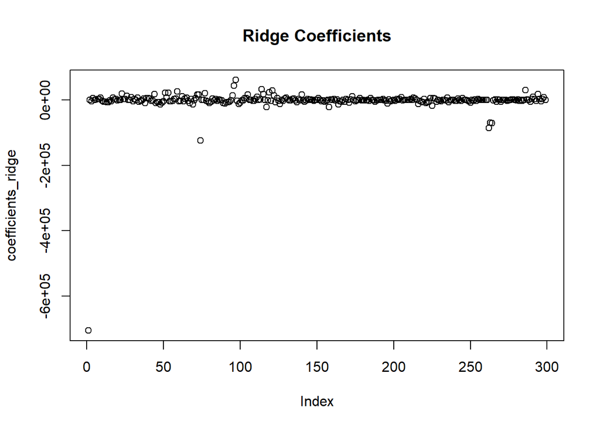

```r
# Create a data frame for plotting
results_df_1 <- data.frame(Predicted = as.vector(predictions_ridge_test), Actual = test$SalePrice)

# Coefficients plot for Ridge model
coefficients_ridge <- coef(ridge_model)
plot(coefficients_ridge, main = "Ridge Coefficients")
```

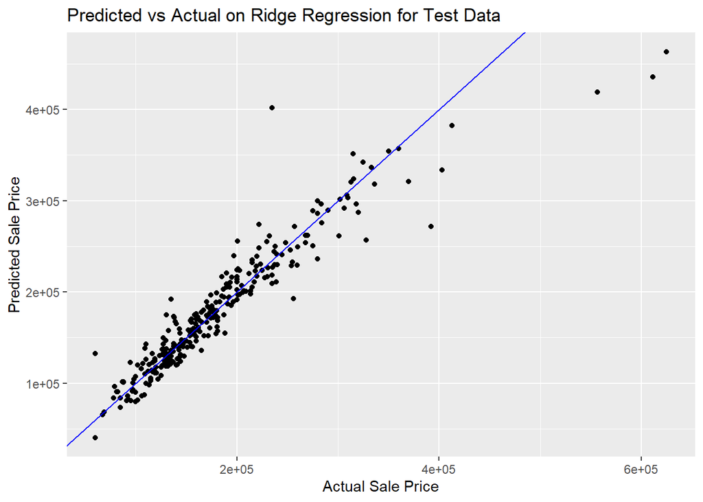

```r
# Predicted vs Actual plot for Ridge model
ggplot(results_df_1, aes(x = Actual, y = Predicted)) +
  geom_point() +
  geom_abline(intercept = 0, slope = 1, col = "blue") +
  ggtitle("Predicted vs Actual on Ridge Regression for Test Data") +
  xlab("Actual Sale Price") +
  ylab("Predicted Sale Price")
```

### Lasso Regression Model

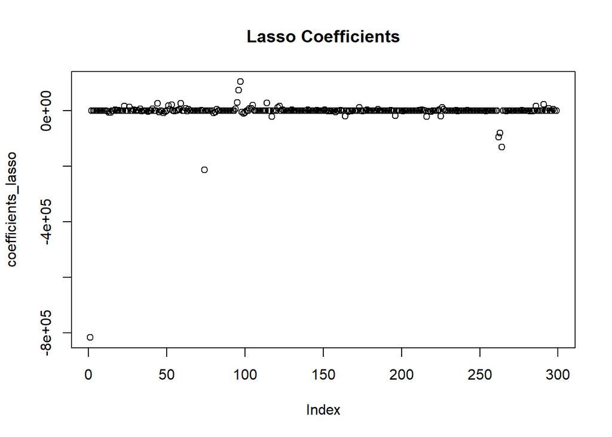

```r
# Create a data frame for plotting
results_df_2 <- data.frame(Predicted = as.vector(predictions_lasso_test), Actual = test$SalePrice)

# Coefficients plot for Ridge model
coefficients_lasso <- coef(lasso_model)
plot(coefficients_lasso, main = "Lasso Coefficients")
```

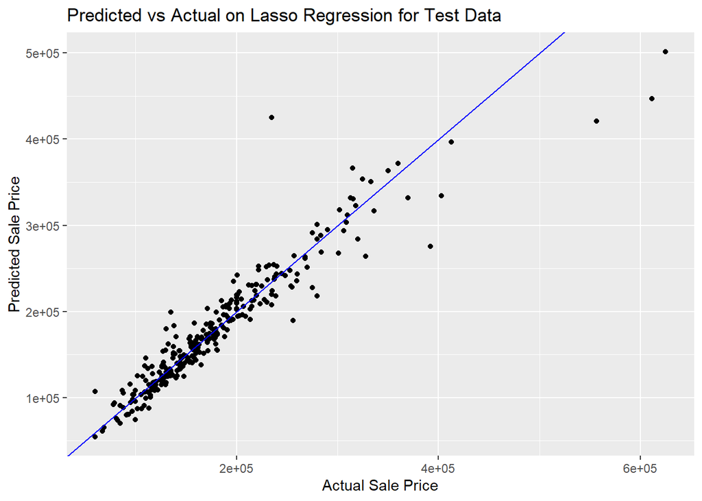

```r
# Predicted vs Actual plot for Lasso model
ggplot(results_df_2, aes(x = Actual, y = Predicted)) +
  geom_point() +
  geom_abline(intercept = 0, slope = 1, col = "blue") +
  ggtitle("Predicted vs Actual on Lasso Regression for Test Data") +
  xlab("Actual Sale Price") +
  ylab("Predicted Sale Price")
```

### Elastic Net Regression

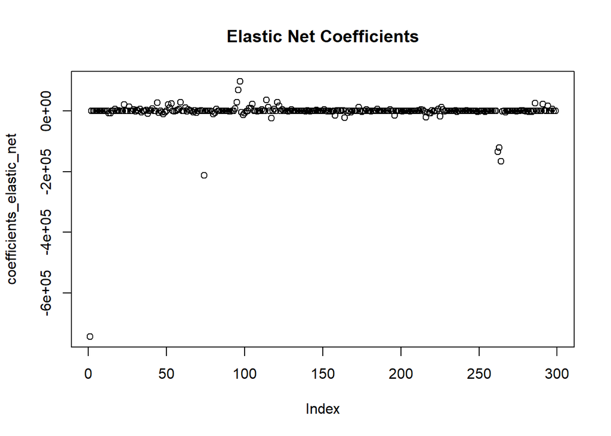

```r
# Create a data frame for plotting
results_df_3 <- data.frame(Predicted = as.vector(predictions_elastic_test), Actual = test$SalePrice)

# Coefficients plot for Ridge model
coefficients_elastic_net <- coef(elastic_net_model)
plot(coefficients_elastic_net, main = "Elastic Net Coefficients")
```

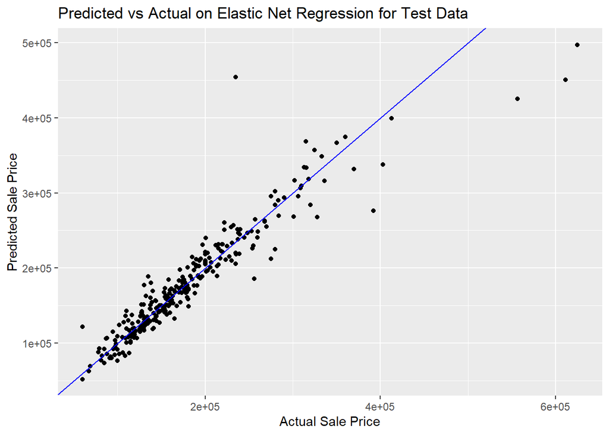

```r
# Predicted vs Actual plot for Lasso model
ggplot(results_df_3, aes(x = Actual, y = Predicted)) +
  geom_point() +
  geom_abline(intercept = 0, slope = 1, col = "blue") +
  ggtitle("Predicted vs Actual on Elastic Net Regression for Test Data") +
  xlab("Actual Sale Price") +
  ylab("Predicted Sale Price")
```

# Support Vector Machines

## Create Data Partition

```r
# Set seed for reproducibility
set.seed(100)

# Split the data

trainIndex <- createDataPartition(hpc_01$SalePrice, p = .8, list = FALSE)

trainData <- hpc_01[trainIndex, ]
testData <- hpc_01[-trainIndex, ]

row_count_train <- nrow(trainData)
row_count_test <- nrow(testData)

row_count_train
```

```
## [1] 1153
```

```r
row_count_test
```

```
## [1] 286
```

```r
round(row_count_train/nrow(hpc_01),2)
```

```
## [1] 0.8
```

```r
round(row_count_test/nrow(hpc_01),2)
```

```
## [1] 0.2
```

## SVM using Linear Kernel

The model below will utilize simple-hold out evaluation to first gauge this model’s performance.

```r
# Train SVM model with a linear kernel
tic()
svm_model_linear <- svm(SalePrice ~ ., data = trainData, kernel = "linear", cost = 1, scale = TRUE)
toc()
```

```
## 3.63 sec elapsed
```

```r
svm_model_linear
```

```
##
## Call:
## svm(formula = SalePrice ~ ., data = trainData, kernel = "linear",
##     cost = 1, scale = TRUE)
##
##
## Parameters:
##    SVM-Type:  eps-regression
##  SVM-Kernel:  linear
##        cost:  1
##       gamma:  0.003355705
##     epsilon:  0.1
##
##
## Number of Support Vectors:  695
```

```r
# Make prediction the train data
predictions_linear_train <- predict(svm_model_linear, newdata = trainData)

# Make predictions on the test data
predictions_linear_test <- predict(svm_model_linear, newdata = testData)

# Evaluating performance on Train Data
mmetric(trainData$SalePrice,predictions_linear_train,metrics_list)
```

```
##          MAE         RMSE           R2          COR         MAPE        RMSPE
## 1.182115e+04 2.113616e+04 9.252390e-01 9.618934e-01 7.013177e+00 1.254664e+00
##          RAE         RRSE
## 2.088153e+01 2.735193e+01
```

```r
# Evaluating performance on Test Data
mmetric(testData$SalePrice,predictions_linear_test, metrics_list)
```

```
##          MAE         RMSE           R2          COR         MAPE        RMSPE
## 1.545378e+04 2.549662e+04 8.957120e-01 9.464206e-01 8.769010e+00 1.302462e+00
##          RAE         RRSE
## 2.766628e+01 3.245450e+01
```

### Hyper parameter Tuning using Cross Validation

There are numerous hyperparamters that could be utilized to improve the model. It however would be inefficient to go through all the hyperparamters. Thus, grid search will be used to help find the best hyperparameters. It should be noted that the kernel will be kept the same.

```r
# Define tuning grid for hyperparameter tuning - different combinations of C
tune_grid <- expand.grid(C = seq(0.1, 2, by = 0.5))

# Perform Cross-Validation for regression
svm_tuned_linear <- train(SalePrice ~ .,
                          data = trainData,
                          method = "svmLinear",
                          tuneGrid = tune_grid,
                          metric = "RMSE", # Use RMSE for regression
                          trControl = trainControl(method = "cv", number = 5))

# Print the best model and parameters
print(svm_tuned_linear)
```

```
## Support Vector Machines with Linear Kernel
##
## 1153 samples
##   79 predictor
##
## No pre-processing
## Resampling: Cross-Validated (5 fold)
## Summary of sample sizes: 922, 923, 924, 921, 922
## Resampling results across tuning parameters:
##
##   C    RMSE      Rsquared   MAE
##   0.1  36130.08  0.7879621  23007.60
##   0.6  35811.69  0.7925817  22589.53
##   1.1  35770.96  0.7920089  22563.47
##   1.6  35518.72  0.7952105  22551.46
##
## RMSE was used to select the optimal model using the smallest value.
## The final value used for the model was C = 1.6.
```

### Model Plot

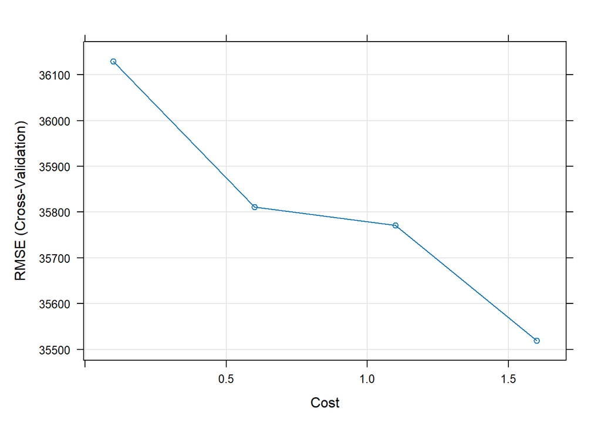

```r
# Plot model
plot(svm_tuned_linear)
```

The plot shows the RMSE score for the model across different C values, where C = 1.6 achieves the lowest RMSE, indicating the best model performance.

## SVM using RBF Kernel

```r
# Train SVM model with RBF kernel
svm_model_rbf <- svm(SalePrice ~ ., data = trainData, kernel = "radial", cost = 1, gamma = 0.1)

svm_model_rbf
```

```
##
## Call:
## svm(formula = SalePrice ~ ., data = trainData, kernel = "radial",
##     cost = 1, gamma = 0.1)
##
##
## Parameters:
##    SVM-Type:  eps-regression
##  SVM-Kernel:  radial
##        cost:  1
##       gamma:  0.1
##     epsilon:  0.1
##
##
## Number of Support Vectors:  857
```

```r
# Make prediction the train data
predictions_rbf_train <- predict(svm_model_rbf, newdata = trainData)

# Make predictions on the test data
predictions_rbf_test <- predict(svm_model_rbf, newdata = testData)

# Evaluating performance on Train Data
mmetric(trainData$SalePrice,predictions_rbf_train,metrics_list)
```

```
##          MAE         RMSE           R2          COR         MAPE        RMSPE
## 1.278839e+04 3.300890e+04 8.571956e-01 9.258486e-01 6.461886e+00 1.205117e+00
##          RAE         RRSE
## 2.259011e+01 4.271622e+01
```

```r
# Evaluating performance on Test Data
mmetric(testData$SalePrice,predictions_rbf_test, metrics_list)
```

```
##          MAE         RMSE           R2          COR         MAPE        RMSPE
## 3.430367e+04 6.104687e+04 4.749815e-01 6.891891e-01 1.965925e+01 3.022800e+00
##          RAE         RRSE
## 6.141248e+01 7.770621e+01
```

Let’s compare the result with the simple linear kernal SVM we trained before.

The comparison between the performance of SVM models with linear and radial kernels on both the training and test datasets highlights the underperformance of the radial kernel in this specific regression task.

**Conclusion:** The linear kernel outperforms the radial kernel in this regression task, providing better accuracy, robustness, and generalization. While radial kernels are powerful for capturing non-linear relationships, their complexity needs careful tuning and justification based on the dataset’s characteristics. In this case, the linear kernel is the more appropriate choice.

### Hyper Parameter Tuning using Cross Validation

```r
# Define tuning grid for tuning hyper parameters - different combinations of C and sigma

tune_grid_rbf <- expand.grid(sigma = c(0.01, 0.05, 0.1), C = c(0.1, 1, 10))

# Perform Cross-Validation for regression
svm_tuned_rbf <- train(SalePrice ~ .,
                          data = trainData,
                          method = "svmRadial",
                          tuneGrid = tune_grid_rbf,
                          metric = ("RMSE"), # Use RMSE for regression
                          trControl = trainControl(method = "cv", number = 5))

# Print the best model and parameters
print(svm_tuned_rbf)
```

```
## Support Vector Machines with Radial Basis Function Kernel
##
## 1153 samples
##   79 predictor
##
## No pre-processing
## Resampling: Cross-Validated (5 fold)
## Summary of sample sizes: 922, 922, 922, 924, 922
## Resampling results across tuning parameters:
##
##   sigma  C     RMSE      Rsquared     MAE
##   0.01    0.1  78919.55  0.003950504  54862.85
##   0.01    1.0  78919.55  0.003950502  54862.84
##   0.01   10.0  78919.53  0.003950502  54862.80
##   0.05    0.1  78919.55  0.003378199  54862.85
##   0.05    1.0  78919.55  0.003378199  54862.84
##   0.05   10.0  78919.54  0.003378199  54862.81
##   0.10    0.1  78919.55  0.002883524  54862.85
##   0.10    1.0  78919.55  0.002883524  54862.84
##   0.10   10.0  78919.54  0.002883524  54862.82
##
## RMSE was used to select the optimal model using the smallest value.
## The final values used for the model were sigma = 0.01 and C = 10.
```

As predicted from the comparison in between the simple Linear and simple Radial kernal SV Models, the radial kernel is not getting the variance at all as can be seen from the extremely low $R^2$ values above.

### Model Plot

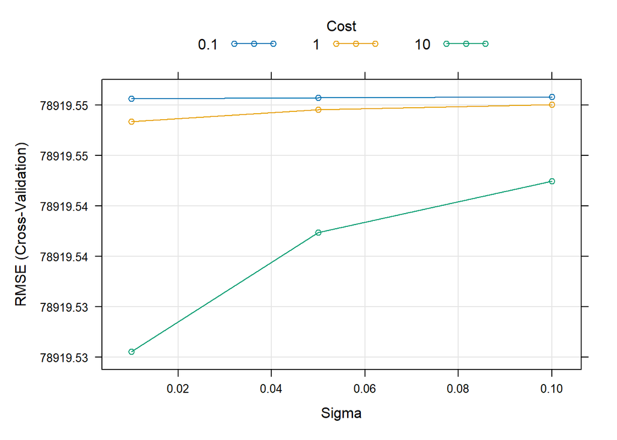

```r
# Plot model
plot(svm_tuned_rbf)
```

## K-fold validation

Since the linear kernel did the best, this model will be evaluated on the entire dataset to further assess performance. The model did use cross-validation to tune the hyperparmaters, however this was only with the train set.

Since, we have now found the best model, we are going to assess it’s performance on the entire dataset. There will be no hyper-paramter tuning of the SVM model. This is just to assess its performance as previously stated.

### Create k-fold function that accepts custom parameter settings

```r
cv_function_ksvm <- function(df, target, nFolds, seedVal, metrics_list, kern, c)
{
# create folds using the assigned values

set.seed(seedVal)
folds = createFolds(df[,target],nFolds)

# The lapply loop

cv_results <- lapply(folds, function(x)
{
# data preparation:

  test_target <- df[x,target]
  test_input <- df[x,-target]

  train_target <- df[-x,target]
  train_input <- df[-x,-target]
   pred_model <- ksvm(train_target ~ .,data = train_input,kernel=kern,C=c)
  pred <- predict(pred_model, test_input)
  return(mmetric(test_target,pred,metrics_list))
})

cv_results_m <- as.matrix(as.data.frame(cv_results))
cv_mean<- as.matrix(rowMeans(cv_results_m))
cv_sd <- as.matrix(rowSds(cv_results_m))
colnames(cv_mean) <- "Mean"
colnames(cv_sd) <- "Sd"
cv_all <- cbind(cv_results_m, cv_mean, cv_sd)

kable(t(cbind(cv_all)),digits=2)
}
```

### Run k-fold function

```r
cv_function_ksvm(hpc_01,79,5,100,metrics_list = metrics_list,"vanilladot",1.6)
```

|  | MAE | RMSE | R2 | COR | MAPE | RMSPE | RAE | RRSE |
| --- | --- | --- | --- | --- | --- | --- | --- | --- |
| Fold1 | 15032.30 | 24439.43 | 0.90 | 0.95 | 8.84 | 1.31 | 26.77 | 31.75 |
| Fold2 | 16338.68 | 22639.10 | 0.92 | 0.96 | 10.26 | 1.63 | 27.94 | 28.68 |
| Fold3 | 15766.52 | 32763.59 | 0.83 | 0.91 | 9.13 | 1.75 | 27.76 | 42.05 |
| Fold4 | 15075.34 | 22317.70 | 0.91 | 0.95 | 9.83 | 1.65 | 27.48 | 30.16 |
| Fold5 | 17837.92 | 30638.85 | 0.85 | 0.92 | 10.08 | 1.70 | 31.79 | 38.51 |
| Mean | 16010.15 | 26559.73 | 0.88 | 0.94 | 9.63 | 1.61 | 28.35 | 34.23 |
| Sd | 1155.22 | 4821.54 | 0.04 | 0.02 | 0.62 | 0.17 | 1.98 | 5.77 |

Function used a slightly different ksvm algorithm, however the results are still the same and the algorithm still uses the linear kernel.

## Simple hold out evaluation for reference

We’ll also do simple hold out evaluation for reference, however the k-fold validation still remains the most robust method of validation since it does not depend on a particular split.

```r
#Create the best model

best_model_ksvm <- ksvm(SalePrice ~ . , data = trainData,kernel = "vanilladot", C = 1.6)
best_model_ksvm_trainpred <- predict(best_model_ksvm,newdata = trainData)

best_model_ksvm_testpred <- predict(best_model_ksvm, newdata = testData)

mmetric(trainData$SalePrice,best_model_ksvm_trainpred,metrics_list)
```

```
##          MAE         RMSE           R2          COR         MAPE        RMSPE
## 1.180465e+04 2.101941e+04 9.260505e-01 9.623152e-01 7.011930e+00 1.249490e+00
##          RAE         RRSE
## 2.085237e+01 2.720085e+01
```

```r
mmetric(testData$SalePrice, best_model_ksvm_testpred,metrics_list)
```

```
##          MAE         RMSE           R2          COR         MAPE        RMSPE
## 1.562495e+04 2.593427e+04 8.918009e-01 9.443521e-01 8.904998e+00 1.343278e+00
##          RAE         RRSE
## 2.797271e+01 3.301158e+01
```

## Visualization of Best Model’s Performance

Shows how well the model performs on the test data.

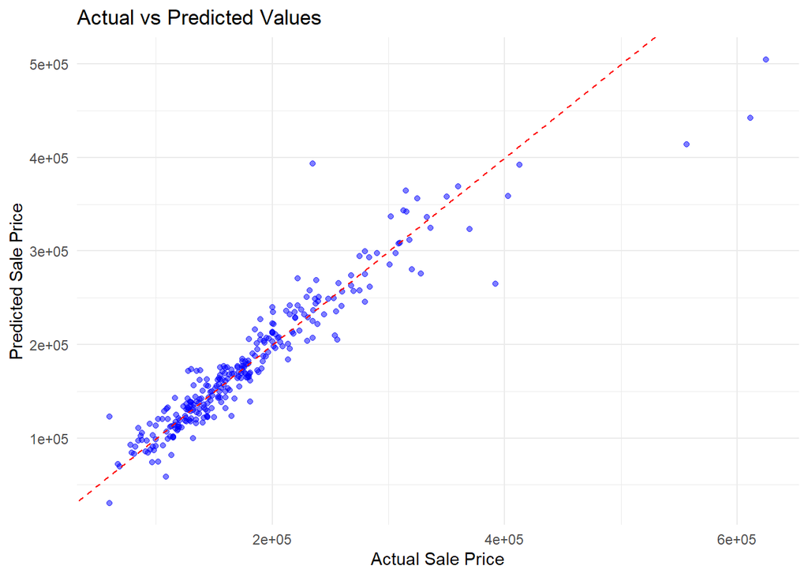

```r
# Create a dataframe with actual and predicted values
results_df <- data.frame(
  Actual = testData$SalePrice,
  Predicted = best_model_ksvm_testpred
)

# Plot Actual vs Predicted
ggplot(results_df, aes(x = Actual, y = Predicted)) +
  geom_point(color = "blue", alpha = 0.5) +  # Scatter plot points
  geom_abline(slope = 1, intercept = 0, color = "red", linetype = "dashed") +  # Perfect fit line
  labs(
    title = "Actual vs Predicted Values",
    x = "Actual Sale Price",
    y = "Predicted Sale Price"
  ) +
  theme_minimal()
```

This model is doing a decent job with most of the points fairly close to the line. There are only a few points which deviate a lot from the line.

## Limitations and Robustness Checks for SVM

**Limitations:**

Overfitting risk: Even though cross-validation was applied, the risk of overfitting still exists, particularly in models with a high number of support vectors (as seen in the RBF kernel). This overfitting could lead to poor generalization when applied to new data.

**Robustness Checks:**

Cross-validation (5-fold): To ensure model stability, 5-fold cross-validation was applied during hyperparameter tuning for both the linear and RBF SVM models. This provided more reliable estimates of model performance by reducing the variance that can arise from a single train-test split.

Grid search for hyperparameter tuning: Extensive grid search was conducted to identify the best values for C (regularization parameter) in both models and sigma (kernel coefficient) for the RBF kernel. This ensures that the models were fine-tuned and optimized for the specific dataset.

# XGBoost

## Modeling

### Split Data into Train and Test Groups

```r
set.seed(123)
house_prices_rn <- initial_split(hpc_01, prop = 0.8,
strata = SalePrice)

HousePrice_train <- training(house_prices_rn)
HousePrice_test <- testing(house_prices_rn)
```

### Grid Search

```r
# Preprocessing with a Recipe
rec_HousePrice <- recipe(SalePrice ~ ., data = HousePrice_train) %>%
  step_dummy(all_nominal_predictors())     #dummify all numeric cols for modelling
```

### Define the Boosted Tree Model with Adjustable Hyperparameters

```r
model_HousePrice <- boost_tree(
  trees = tune(),         # Number of trees in the ensemble
  tree_depth = tune(),    # Maximum depth of each tree
  learn_rate = tune(),    # Learning rate
  mtry = tune(),          # Number of predictors to sample at each split
  min_n = tune(),         # Minimum number of data points in a node
  loss_reduction = tune(),# Minimum loss reduction for a split
  sample_size = tune()    # Proportion of data for each tree
) %>%
set_engine("xgboost", verbosity = 0) %>%
set_mode("regression")


model_HousePrice
```

```
## Boosted Tree Model Specification (regression)
##
## Main Arguments:
##   mtry = tune()
##   trees = tune()
##   min_n = tune()
##   tree_depth = tune()
##   learn_rate = tune()
##   loss_reduction = tune()
##   sample_size = tune()
##
## Engine-Specific Arguments:
##   verbosity = 0
##
## Computational engine: xgboost
```

### Create Hyperparameter Grid for Tuning

```r
# Define the hyperparameter grid
hyper_grid <- grid_random(
  trees(range = c(2, 500)),             # Number of trees in the ensemble
  tree_depth(range = c(2, 10)),          # Maximum depth of each tree
  learn_rate(range = c(0.01, 0.3)),      # Learning rate
  finalize(mtry(), HousePrice_train),    # Number of predictors to sample at each split
  min_n(range = c(2, 10)),               # Minimum number of data points in a node
  loss_reduction(range = c(0, 3)),       # Minimum loss reduction for a split
  sample_size = sample_prop(c(0.6, 0.9)),  # Proportion of data for each tree
  size = 200
)
```

### Perform 3-fold Cross Validation

```r
HousePrice_folds <- vfold_cv(HousePrice_train, v = 3)
```

### Define Workflow

```r
# Combine model specification and recipe into a single workflow for streamlined tuning and evaluation

HousePrice_wf <- workflow() %>%
add_model(model_HousePrice) %>%
add_recipe(rec_HousePrice)

# See how many cores are available on local machine
num_cores <- detectCores()
num_cores
```

```
## [1] 8
```

## Hyperparameter Tuning with Grid Search

```r
# Hyperparameter Tuning with Grid Search
doParallel::registerDoParallel(cores = num_cores)

# Run the tuning process with both rmse and rsq metrics
set.seed(1234)
HousePrice_tune <- HousePrice_wf %>%
  tune_grid(
    resamples = HousePrice_folds,
    grid = hyper_grid,
    metrics = metric_set(rmse, rsq)  # Include both rmse and rsq
  )

# Stop parallel processing
doParallel::stopImplicitCluster()
# Collect metrics from the tuning results
HousePrice_metrics <- HousePrice_tune %>%
  collect_metrics() %>%
  pivot_wider(names_from = .metric, values_from = mean)

# Filter rows with non-missing values for rmse and rsq separately
HousePrice_rmse <- HousePrice_metrics %>%
  filter(!is.na(rmse)) %>%
  arrange(rmse) %>%
  head(1) # Select the model with the lowest RMSE

HousePrice_rsq <- HousePrice_metrics %>%
  filter(!is.na(rsq)) %>%
  arrange(desc(rsq)) %>%
  head(1) # Select the model with the highest R²

# Print the metrics and the best models for rmse and rsq

print(HousePrice_rmse)
```

```
## # A tibble: 1 × 13
##    mtry trees min_n tree_depth learn_rate loss_reduction sample_size .estimator
##   <int> <int> <int>      <int>      <dbl>          <dbl>       <dbl> <chr>
## 1     5   306     6          2       1.15           24.6       0.892 standard
## # ℹ 5 more variables: n <int>, std_err <dbl>, .config <chr>, rmse <dbl>,
## #   rsq <dbl>
```

```r
print(HousePrice_rsq)
```

```
## # A tibble: 1 × 13
##    mtry trees min_n tree_depth learn_rate loss_reduction sample_size .estimator
##   <int> <int> <int>      <int>      <dbl>          <dbl>       <dbl> <chr>
## 1    10    34     4          2       1.12           282.       0.789 standard
## # ℹ 5 more variables: n <int>, std_err <dbl>, .config <chr>, rmse <dbl>,
## #   rsq <dbl>
```

Aggregate results and select the best-performing model based on low RMSE and high R², balancing accuracy and predictive power.

```r
best_model_rmse <- HousePrice_tune %>%
  select_best(metric = "rmse")

best_model_rmse
```

| mtry | trees | min_n | tree_depth | learn_rate | loss_reduction | sample_size | .config |
| --- | --- | --- | --- | --- | --- | --- | --- |
| 5 | 306 | 6 | 2 | 1.145587 | 24.63023 | 0.8919679 | Preprocessor1_Model007 |

```r
best_model_rsq <- HousePrice_tune %>%
  select_best(metric = "rsq")

best_model_rsq
```

| mtry | trees | min_n | tree_depth | learn_rate | loss_reduction | sample_size | .config |
| --- | --- | --- | --- | --- | --- | --- | --- |
| 10 | 34 | 4 | 2 | 1.123282 | 281.8862 | 0.789059 | Preprocessor1_Model005 |

## Evaluate on Test Dataset

```r
final_workflow_rmse <-
HousePrice_wf %>%
finalize_workflow(best_model_rmse)

final_workflow_rsq <-
HousePrice_wf %>%
finalize_workflow(best_model_rsq)


final_fit_rmse <-
final_workflow_rmse %>%
last_fit(split = house_prices_rn)

final_fit_rmse %>%
collect_metrics() %>%
    mutate_if(is.numeric, round, 2)
```

| .metric | .estimator | .estimate | .config |
| --- | --- | --- | --- |
| rmse | standard | 42764.77 | Preprocessor1_Model1 |
| rsq | standard | 0.73 | Preprocessor1_Model1 |

```r
final_fit_rsq <-
final_workflow_rsq %>%
last_fit(split = house_prices_rn)

final_fit_rsq %>%
collect_metrics() %>%
    mutate_if(is.numeric, round, 2)
```

| .metric | .estimator | .estimate | .config |
| --- | --- | --- | --- |
| rmse | standard | 43754.37 | Preprocessor1_Model1 |
| rsq | standard | 0.73 | Preprocessor1_Model1 |

This is a good model, the model is not overfitting and generalizing almost perfectly to new data. R^2 slightly increased from 0.71% to 0.73%. The RMSE has also decreased from 44660 dollars to 43754 dollars. Training metrics (from cross-validation) show high R² and low RMSE, which can also be seen in the performance on the test.

### Graphs

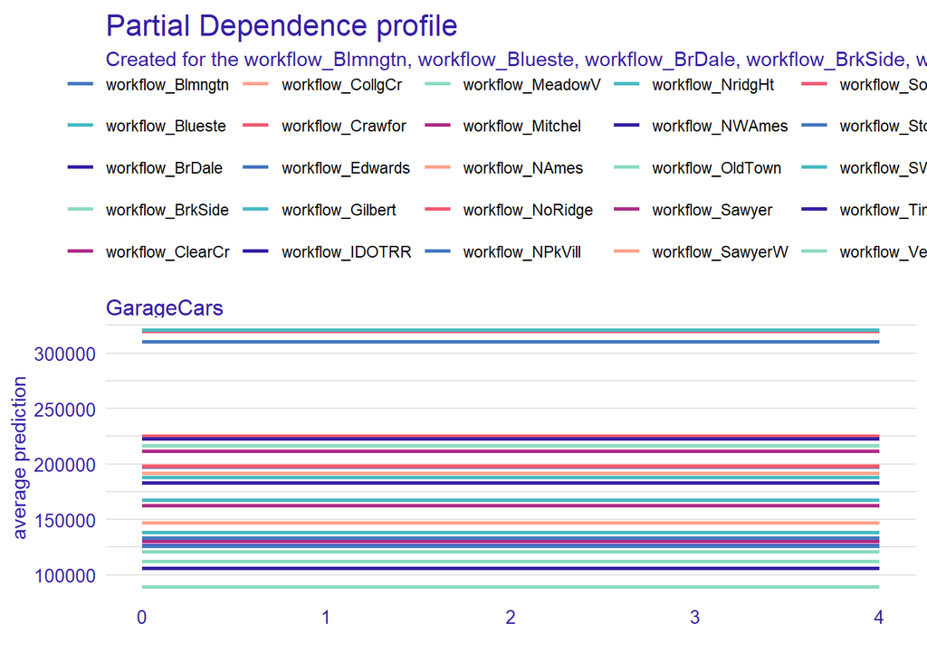

```r
library(DALEXtra)

model_fitted <- final_workflow_rsq %>%
fit(data = HousePrice_train)

explainer_rf <- explain_tidymodels(model_fitted,
data = HousePrice_train[,-79],
y = HousePrice_train$SalePrice,
type = "pdp",verbose = FALSE)

garagecars_comp <- model_profile(explainer_rf,
variables = "GarageCars",
groups = "Neighborhood",N=NULL)

# Plotting the variable profile
plot(garagecars_comp)
```

## Assumptions, Limitations and Robustness Checks for XGBoost (Boosting)

**Assumptions**

The primary assumption was that the relationship between the predictors and the target variable is non-linear. We also assumed that there is no significant multicollinearity among the predictors or with the target variable. The data was expected to be unnormalized and potentially skewed, as XGBoost can handle skewed data effectively by focusing on regions where errors are high. Certain missing values were assumed to be managed automatically by XGBoost.

**Limitations**

The dataset used for this analysis is limited to one location, so generalization to other regions might not be straightforward.

Xgboost being a complex and robust model, is less interpretable than simpler linear models, making it harder to directly understand the impact of individual features on predictions.

As observed in few results, the model might show signs of overfitting, which indicates that it may not generalize well to new data without additional tuning or regularization.

The dataset is limited and may not capture external causal features affecting house prices, such as economic conditions or neighborhood developments, which may limit the model’s predictive scope.

**Robustness checks:**

A grid search was conducted to identify optimal parameters, followed by a 3-fold cross-validation. The xgboost itself is robust, but further checks were performed by re-evaluating the best parameters and refining the model through a finalized workflow.

3-fold cross validation was performed on the best model by collecting additional metrics such as R-squared, MAE (Mean Absolute Error), and MAPE (Mean Absolute Percentage Error) apart from RMSE (Root Mean Squared Error). Finally, model performance was compared and assessed with the test set to check for generalizability, although the additional cross-validation check did not show proving results.

Our outcome has been affected by the cleaning decisions that we have used when cleaning the data. There are numerous ways and approaches to cleaning the data. For instance, we did not consider low-variance columns and imputed missing values for a with median/mode for a few columns which may introduce biases if the missing values are not random. (Based on our analysis for some of the columns like Lot Frontage, they appeared random, but this could not be the case. There was no strong evidence or documention to suggest that missing values conveyed something else like with the other variables like Fireplace Qu where missing values mean that there is no fireaplce.)

Additionally, we utilized simple imputation as opposed to utilizing a more complicated package like MICE. It is possible that our results would change if we had decided to take another approach.

Likewise, we adopted a very conservative approach with outliers since some extreme observations may be valid observations. This however will cause the residuals to increase and consequently any additional regression tree will work harder to correct for these larger residuals. This can consequently increase in sightly more overfitting. This issue however was avoided by hyperparameter tuning like reducing the tree depth for instance to 1.

We also created another column that was originally not apart of the dataset to explicitly record whether a house had a garage or not. Although this column ultimately didn’t end up being important, it’s still another column that XGboost must decide whether to keep or drop when making predictions.

# Principal Component Analysis (PCA)

## Binning the SalePrice Variable

```r
# Display the structure of the data

hp <- hpc_01


#Handle Target Variable: create 10 bins
bin_breaks <- seq(min(hp$SalePrice, na.rm = TRUE),  #find min price
                  max(hp$SalePrice, na.rm = TRUE),  #find max price
                  length.out = 11)      # 11 values, creating 10 equal intervals (bins)

bin_breaks
```

```
##  [1]  34900 105910 176920 247930 318940 389950 460960 531970 602980 673990
## [11] 745000
```

```r
# Create separate column for binned SalePrice
hp <- hp %>%
  mutate(SalePrice_Bin = cut(SalePrice, breaks = bin_breaks, include.lowest = TRUE, labels = FALSE)) %>%
  mutate(SalePrice_Bin = as.factor(SalePrice_Bin))

# Remove main SalePrice column
hp <- hp %>%
  select(-SalePrice)

# Check the distribution of binned SalePrice:
table(hp$SalePrice_Bin)
```

```
##
##   1   2   3   4   5   6   7   8   9  10
## 140 704 374 140  49  20   5   4   2   1
```

```r
#check structure of binned SalePrice
summary(hp$SalePrice_Bin)
```

```
##   1   2   3   4   5   6   7   8   9  10
## 140 704 374 140  49  20   5   4   2   1
```

```r
str(hp$SalePrice_Bin)
```

```
##  Factor w/ 10 levels "1","2","3","4",..: 3 3 3 2 4 2 4 3 2 2 ...
```

We do not use any dependent variables in exploratory analysis methods. Remove the dependent variable or treat it as an independent categorical variable. Use bin breaks to categorize the SalePrice values into bins (low, medium, high price houses). The majority of the data points fall into bins 2 and 3, indicating that most houses have a low SalePrice, also indicating right skewed distribution. The higher bins (7 to 10) have very few observations, suggesting that very few houses have too expensive prices.

## Standardize the Data

```r
# Standardize numeric columns for mean =0 , sd = 1

scales <- build_scales(hp, verbose = TRUE)
```

```
##  [1] "MSSubClass"    "MSZoning"      "Street"        "Alley"
##  [5] "LotShape"      "LandContour"   "Utilities"     "LotConfig"
##  [9] "LandSlope"     "Neighborhood"  "Condition1"    "Condition2"
## [13] "BldgType"      "HouseStyle"    "OverallQual"   "OverallCond"
## [17] "RoofStyle"     "RoofMatl"      "Exterior1st"   "Exterior2nd"
## [21] "MasVnrType"    "ExterQual"     "ExterCond"     "Foundation"
## [25] "BsmtQual"      "BsmtCond"      "BsmtExposure"  "BsmtFinType1"
## [29] "BsmtFinType2"  "Heating"       "HeatingQC"     "CentralAir"
## [33] "Electrical"    "KitchenQual"   "Functional"    "FireplaceQu"
## [37] "GarageType"    "GarageFinish"  "GarageQual"    "GarageCond"
## [41] "PavedDrive"    "PoolQC"        "Fence"         "MiscFeature"
## [45] "MoSold"        "SaleType"      "SaleCondition" "HasGarage"
## [49] "SalePrice_Bin"
## [1] "build_scales: c(\"MSSubClass\", \"MSZoning\", \"Street\", \"Alley\", \"LotShape\", \"LandContour\", \"Utilities\", \"LotConfig\", \"LandSlope\", \"Neighborhood\", \"Condition1\", \"Condition2\", \"BldgType\", \"HouseStyle\", \"OverallQual\", \"OverallCond\", \"RoofStyle\", \"RoofMatl\", \"Ex…
## [1] "build_scales: I will compute scale on  31 numeric columns."
## [1] "build_scales: it took me: 0s to compute scale for 31 numeric columns."
```

```r
hp <- fast_scale(hp, scales = scales, verbose = TRUE)
```

```
## [1] "fast_scale: I will scale 31 numeric columns."
## [1] "fast_scale: it took me: 0.01s to scale 31 numeric columns."
```

Standardization ensures that all features contribute equally, preventing features with larger scales from dominating the analysis. The fastScale function quickly scales the numeric columns.

## Covariance Matrix

```r
# Handle NA's

library(data.table)

sum(is.na(hp))
```

```
## [1] 0
```

```r
# Impute NA's with column median
hp_num <- lapply(hp, function(x) {
  if (is.numeric(x)) {
    x[is.na(x)] <- median(x, na.rm = TRUE)
  }
  return(x)
})

sum(is.na(hp_num))
```

```
## [1] 0
```

```r
# Convert to data frame

hp_num <- as.data.table(hp_num)


# Filter only numeric columns using .SD
hp_num <- hp_num[, .SD, .SDcols = sapply(hp_num, is.numeric)]

# Check the structure of the cleaned numeric data
str(hp_num)                                         # 32 num cols
```

```
## Classes 'data.table' and 'data.frame':   1439 obs. of  31 variables:
##  $ LotFrontage  : num  -0.2156 0.508 -0.0709 -0.4568 0.701 ...
##  $ LotArea      : num  -0.231 -0.0681 0.1658 -0.0751 0.5923 ...
##  $ YearBuilt    : num  1.049 0.157 0.983 -1.857 0.95 ...
##  $ YearRemodAdd : num  0.876 -0.432 0.827 -0.722 0.731 ...
##  $ MasVnrArea   : num  0.527 -0.573 0.336 -0.573 1.391 ...
##  $ BsmtFinSF1   : num  0.627 1.257 0.117 -0.509 0.509 ...
##  $ BsmtFinSF2   : num  -0.286 -0.286 -0.286 -0.286 -0.286 ...
##  $ BsmtUnfSF    : num  -0.9449 -0.6423 -0.3035 -0.0641 -0.177 ...
##  $ TotalBsmtSF  : num  -0.465 0.509 -0.311 -0.705 0.228 ...
##  $ X1stFlrSF    : num  -0.8042 0.2819 -0.633 -0.5233 -0.0311 ...
##  $ X2ndFlrSF    : num  1.173 -0.797 1.201 0.947 1.632 ...
##  $ LowQualFinSF : num  -0.121 -0.121 -0.121 -0.121 -0.121 ...
##  $ GrLivArea    : num  0.398 -0.484 0.547 0.411 1.358 ...
##  $ BsmtFullBath : num  1.132 -0.822 1.132 1.132 1.132 ...
```

[output cut: 18 more lines]

```r
#covariance matrix
cov_matrix <- cov(hp_num)

# Display  matrix
print(round(cov_matrix, 3))
```

```
##               LotFrontage LotArea YearBuilt YearRemodAdd MasVnrArea BsmtFinSF1
## LotFrontage         1.000   0.314     0.118        0.091      0.164      0.151
## LotArea             0.314   1.000     0.021        0.050      0.138      0.170
## YearBuilt           0.118   0.021     1.000        0.593      0.311      0.249
## YearRemodAdd        0.091   0.050     0.593        1.000      0.174      0.125
## MasVnrArea          0.164   0.138     0.311        0.174      1.000      0.239
## BsmtFinSF1          0.151   0.170     0.249        0.125      0.239      1.000
## BsmtFinSF2          0.037   0.054    -0.050       -0.065     -0.072     -0.060
## BsmtUnfSF           0.128   0.044     0.154        0.185      0.115     -0.515
## TotalBsmtSF         0.306   0.244     0.402        0.301      0.342      0.465
## X1stFlrSF           0.380   0.310     0.283        0.243      0.321      0.392
## X2ndFlrSF           0.065   0.081     0.003        0.138      0.157     -0.164
## LowQualFinSF        0.042   0.014    -0.185       -0.063     -0.069     -0.066
## GrLivArea           0.339   0.299     0.193        0.290      0.363      0.143
## BsmtFullBath        0.077   0.089     0.185        0.121      0.082      0.653
## BsmtHalfBath       -0.009   0.077    -0.038       -0.010      0.014      0.073
## FullBath            0.190   0.162     0.472        0.441      0.266      0.055
## HalfBath            0.039   0.026     0.240        0.183      0.194     -0.012
## BedroomAbvGr        0.257   0.173    -0.073       -0.043      0.092     -0.111
## KitchenAbvGr       -0.001  -0.016    -0.177       -0.151     -0.037     -0.083
## TotRmsAbvGrd        0.317   0.226     0.091        0.192      0.269      0.015
## Fireplaces          0.214   0.285     0.142        0.114      0.236      0.233
## GarageCars          0.283   0.189     0.543        0.426      0.364      0.224
## GarageArea          0.312   0.204     0.489        0.382      0.367      0.271
## WoodDeckSF          0.087   0.143     0.227        0.214      0.153      0.180
## OpenPorchSF         0.116   0.127     0.185        0.225      0.113      0.090
## EnclosedPorch       0.018  -0.009    -0.388       -0.197     -0.109     -0.101
## X3SsnPorch          0.069   0.036     0.032        0.045      0.020      0.030
## ScreenPorch         0.040   0.073    -0.052       -0.037      0.064      0.069
## PoolArea            0.105   0.049    -0.008       -0.001     -0.027      0.050
## MiscVal            -0.003   0.034    -0.078       -0.046     -0.030     -0.007
## YrSold              0.006  -0.038    -0.010        0.043     -0.006      0.017
##               BsmtFinSF2 BsmtUnfSF TotalBsmtSF X1stFlrSF X2ndFlrSF LowQualFinSF
## LotFrontage        0.037     0.128       0.306     0.380     0.065        0.042
## LotArea            0.054     0.044       0.244     0.310     0.081        0.014
## YearBuilt         -0.050     0.154       0.402     0.283     0.003       -0.185
## YearRemodAdd      -0.065     0.185       0.301     0.243     0.138       -0.063
## MasVnrArea        -0.072     0.115       0.342     0.321     0.157       -0.069
## BsmtFinSF1        -0.060    -0.515       0.465     0.392    -0.164       -0.066
## BsmtFinSF2         1.000    -0.206       0.104     0.095    -0.105        0.015
```

[output cut: 137 more lines]

```
## HalfBath            0.067    0.002  -0.059 -0.003
## BedroomAbvGr        0.031    0.053   0.022 -0.032
## KitchenAbvGr       -0.052   -0.012   0.051  0.034
## TotRmsAbvGrd        0.045    0.031  -0.008 -0.026
## Fireplaces          0.180    0.053   0.023 -0.018
## GarageCars          0.052    0.018  -0.074 -0.033
## GarageArea          0.055    0.025  -0.058 -0.022
## WoodDeckSF         -0.069    0.085   0.000  0.026
## OpenPorchSF         0.069    0.025  -0.004 -0.054
## EnclosedPorch      -0.083    0.068   0.012 -0.009
## X3SsnPorch         -0.032   -0.007   0.013  0.019
## ScreenPorch         1.000   -0.016   0.058  0.020
## PoolArea           -0.016    1.000  -0.008 -0.055
## MiscVal             0.058   -0.008   1.000  0.080
## YrSold              0.020   -0.055   0.080  1.000
```

The covariance matrix captures correlation between the features. Large positive values indicate strong positive relationships, while large negative values indicate strong negative relationships. Zero correlation indicates no observed relationship.

## Perform PCA

```r
# Compute Eigen values and vectors to identify PC's

# Perform Eigen decomposition

eigen_result <- eigen(cov_matrix)

eigenvalues <- eigen_result$values

eigenvectors <- eigen_result$vectors

length(eigenvalues)          # 33 PC's
```

```
## [1] 31
```

```r
# Variance explained by each PC
variance_explained <- round(eigenvalues / sum(eigenvalues), 3)
cumulative_variance <- cumsum(variance_explained)

# Display the cumulative variance
print(cumulative_variance)
```

```
##  [1] 0.197 0.297 0.363 0.425 0.467 0.505 0.541 0.576 0.610 0.643 0.675 0.705
## [13] 0.735 0.764 0.792 0.819 0.843 0.866 0.887 0.907 0.925 0.943 0.956 0.968
## [25] 0.978 0.985 0.991 0.995 0.998 0.998 0.998
```

The eigenvalues indicate the amount of variance captured by each principal component. The eigenvector indicates the direction of the component. Cumulative variance helps us decide how many PC’s to retain. The first 16 PC’s explain 82% variance in the data, and hence we retain these and discard the remaining ones.

```r
# Transform data using top PC's

# Convert to matrix for multiplication
house_data_matrix <- as.matrix(hp_num)

# Use first 16 PC's
pca_transformed <- house_data_matrix %*% eigenvectors[, 1:16]

# Convert to a data frame for easier handling
pca_df <- as.data.frame(pca_transformed)
colnames(pca_df) <- paste0("PC", 1:16)

# Display the head of the PCA-transformed data
head(pca_df)
```

|  | PC1 | PC2 | PC3 | PC4 | PC5 | PC6 | PC7 | PC8 | PC9 | PC10 | PC11 | PC12 | PC13 | PC14 | PC15 | PC16 |
| --- | --- | --- | --- | --- | --- | --- | --- | --- | --- | --- | --- | --- | --- | --- | --- | --- |
| 1 | -1.0927505 | 0.4318696 | -1.1109834 | 2.33759342 | -1.1309861 | 0.09449446 | 0.2021565 | 0.4991091 | -0.01896715 | 0.3599624 | -0.54300773 | -0.43979190 | -0.16197898 | 0.28169865 | 0.27942092 | -0.3993375 |
| 2 | -0.2451810 | -1.2151502 | 0.7267024 | -0.13352588 | 1.2034257 | 0.88653404 | -3.3917165 | -0.7225171 | -1.41915972 | 0.5460199 | 0.85990962 | 0.64090787 | -0.55900286 | 1.17435628 | 0.12421436 | -0.5283729 |
| 3 | -1.2817053 | 0.2360112 | -1.0321840 | 1.82581525 | -0.3026119 | -0.09207488 | 0.2833062 | 0.4929634 | 0.30766400 | -0.1500371 | -0.23687956 | -0.23847073 | -0.01621301 | -0.05265557 | 0.20168444 | -0.1928416 |
| 4 | 0.6460449 | 1.2074951 | 1.7082256 | -0.04891827 | 0.1566745 | 1.27025829 | 1.0808917 | 2.6009691 | 0.54571155 | -2.2422731 | 0.21976076 | -1.11247987 | 0.29949967 | 2.25957122 | -0.01172603 | 1.1064000 |
| 5 | -4.1728922 | 0.7909943 | -0.2777810 | 1.87774377 | -0.5326526 | 0.12543321 | -0.1077705 | 0.3782123 | 0.02905160 | -0.5822017 | -0.05311162 | -0.03193762 | -0.09108670 | -0.14261612 | 0.76917924 | 0.0565578 |
| 6 | 0.8720654 | -1.7511807 | -0.6510089 | 1.82319651 | -0.4008341 | -1.91243033 | -4.5510119 | 0.5210144 | 7.93286645 | 1.4882750 | -5.01645764 | -1.00421226 | 1.11532441 | -0.20667113 | -1.82500452 | 3.5082451 |

## Check for Correlation

```r
# Calculate the correlation matrix

round(cor(pca_df),3)
```

```
##      PC1 PC2 PC3 PC4 PC5 PC6 PC7 PC8 PC9 PC10 PC11 PC12 PC13 PC14 PC15 PC16
## PC1    1   0   0   0   0   0   0   0   0    0    0    0    0    0    0    0
## PC2    0   1   0   0   0   0   0   0   0    0    0    0    0    0    0    0
## PC3    0   0   1   0   0   0   0   0   0    0    0    0    0    0    0    0
## PC4    0   0   0   1   0   0   0   0   0    0    0    0    0    0    0    0
## PC5    0   0   0   0   1   0   0   0   0    0    0    0    0    0    0    0
## PC6    0   0   0   0   0   1   0   0   0    0    0    0    0    0    0    0
## PC7    0   0   0   0   0   0   1   0   0    0    0    0    0    0    0    0
## PC8    0   0   0   0   0   0   0   1   0    0    0    0    0    0    0    0
## PC9    0   0   0   0   0   0   0   0   1    0    0    0    0    0    0    0
## PC10   0   0   0   0   0   0   0   0   0    1    0    0    0    0    0    0
## PC11   0   0   0   0   0   0   0   0   0    0    1    0    0    0    0    0
## PC12   0   0   0   0   0   0   0   0   0    0    0    1    0    0    0    0
## PC13   0   0   0   0   0   0   0   0   0    0    0    0    1    0    0    0
## PC14   0   0   0   0   0   0   0   0   0    0    0    0    0    1    0    0
## PC15   0   0   0   0   0   0   0   0   0    0    0    0    0    0    1    0
## PC16   0   0   0   0   0   0   0   0   0    0    0    0    0    0    0    1
```

Since principal components are orthogonal to each other, they are uncorrelated with any other principal component except itself.

# K-Means Clustering

```r
scaled_data <- hp_num

# Convert list to data frame
scaled_data <- as.data.frame(scaled_data)

# Checking for missing or infinite values in the dataset
any(is.na(scaled_data))     # Returns TRUE if there are any NAs
```

```
## [1] FALSE
```

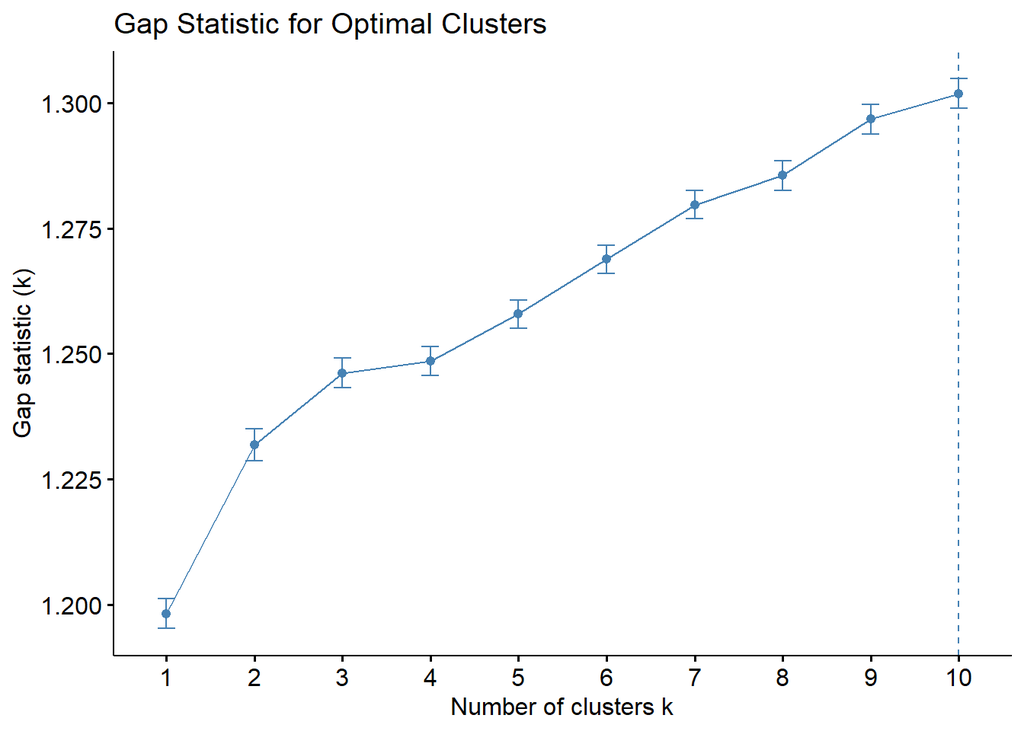

```r
# Removing rows with NA values
scaled_data <- na.omit(scaled_data)  # Removes rows with NA values

library(cluster)

# Compute gap statistic to find the optimal number of clusters
gap_stat <- clusGap(scaled_data, FUN = function(x, k) kmeans(x, centers = k, nstart = 25, iter.max = 100), K.max = 10, B = 50)
fviz_gap_stat(gap_stat) +
  labs(title = "Gap Statistic for Optimal Clusters")
```